# Default-Rate Driver Scan

Dataset · [Home Credit Default Risk Competition](https://www.kaggle.com/competitions/home-credit-default-risk)

Evan Reynolds

October 2026

## The short version

~8%of applicants hit repayment difficulty

Across **307,000+ applications**, a handful of signals separate that 8% cleanly:

- **External credit scores** — by far the strongest
- **Age & job tenure** — younger, less-tenured default more
- **Affordability ratios** — repayment size *relative* to the loan

And one thing that barely matters alone: **the raw loan amount**.

This deck is the *scan* — which fields carry signal — before any model is built. Every rate is read against the **8% base rate**.

## The data in one slide

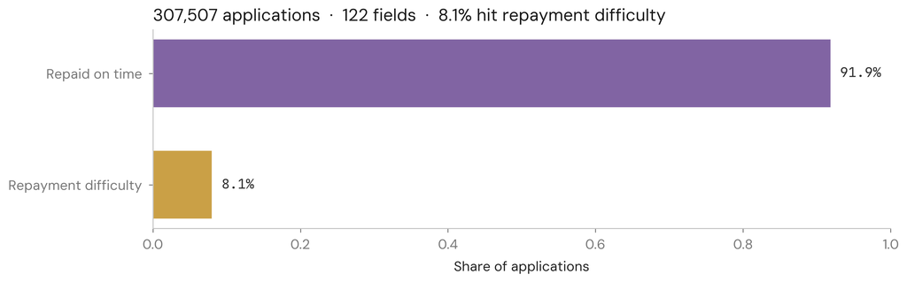

The classes are **imbalanced** — roughly 12 good for every 1 bad. That’s normal for credit, and it’s why every group is read against the 8% line rather than a 50/50 split.

## How to read a driver

For each field we sort applicants into bins (low → high) and check the **default rate in each bin** against the 8% base line.

- Bars that **slope** — the field separates good from bad → useful signal.
- Bars that stay **flat** on the line — no signal → drop it.

Colour just re-states height: lighter = safer, the deeper the purple, the higher the default rate.

That’s the whole method. The next slides are this one chart, one field at a time.

## Strongest signal — external credit scores

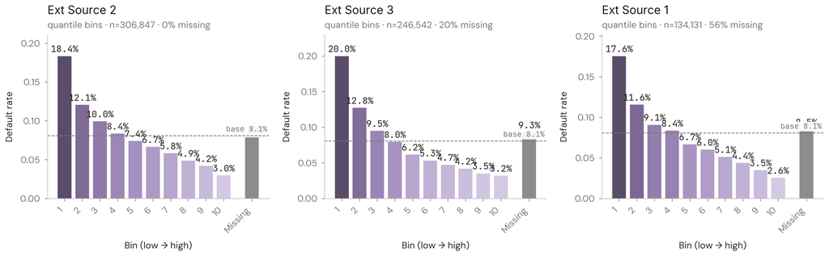

A clean, steep slide from **~20% default in the lowest-score bin to ~2–3% in the highest**. These pre-built external scores are the single best predictors in the data.

## Age & job tenure

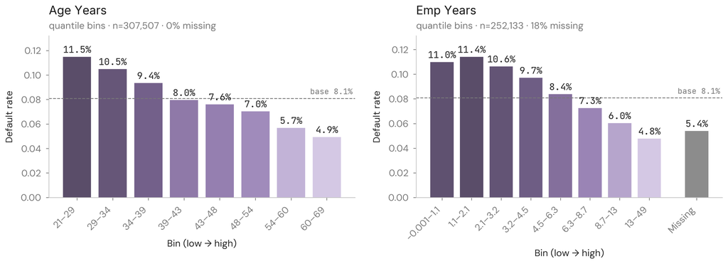

Both slope the intuitive way: **younger applicants, and those with less time in a job, default more**. Stability reads as lower risk. (The “missing” tenure bar is pensioners — correctly low-risk.)

## Education tells a clean story too

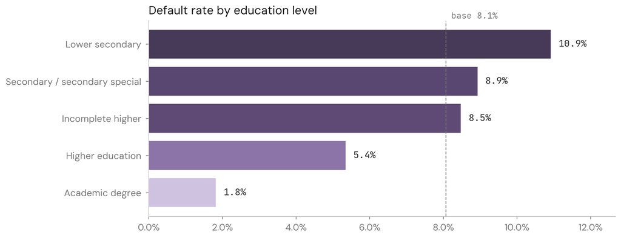

## The surprise — loan amounts barely matter

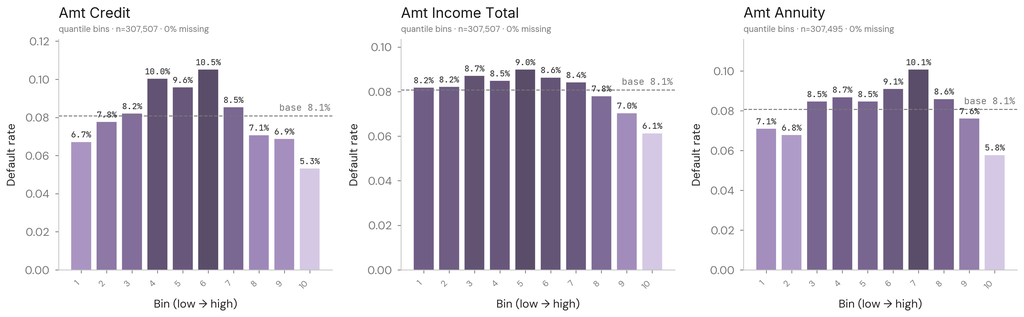

As **raw amounts**, these are nearly flat — a big loan is not, by itself, a risky loan. The signal isn’t the size; it’s the size *relative* to income and the asset. That motivates the engineered ratios.

## Engineered affordability ratios

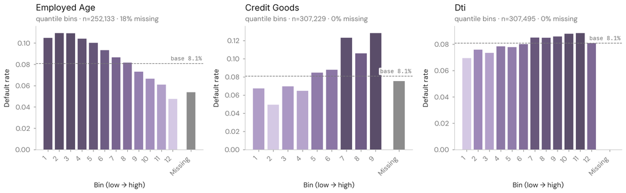

**Job-tenure share** and **loan-to-value** (`CREDIT_GOODS`) slope cleanly — the affordability signal the raw amounts lacked. But **debt-to-income (`DTI`) is flat**: the textbook metric underperforms here, almost certainly because self-reported income is noisy.

## What we carry forward

**Retained** as candidate drivers for the modelling screen:

- **External scores** (strongest), **age & tenure**, **education**
- **Affordability ratios** — loan-to-value and tenure-share
- Weak-but-documented: DTI / income ratios (kept to *show* they underperform)

**Deliberately parked** (reversible, one line to re-add):

- Social-circle and bureau-enquiry counts — too weak to earn a baseline slot

A **lean, defensible shortlist** beats a kitchen sink — it’s the judgment call, not the field count, that matters.

## Caveats & what’s next

- **Gender is excluded** from any model — responsible-lending / anti-discrimination — and used for context only.
- The model **leans heavily on opaque external scores**; self-reported income is noisy.
- Application-time data only; **missing values are kept as their own group** where the absence is itself informative.

**Next:** turn this scan into a ranked screen (WOE / Information Value), then a first interpretable scorecard. This deck answers *“what looks predictive”*; the next answers *“how strongly, and in what order.”*

From scan to scorecard.

This deck answered *what looks predictive*. Next: rank every driver by Information Value, then build a first interpretable, leakage-safe scorecard.

Default-Rate Driver Scan · Home Credit · Flagship PD Model